# SSE0_VSG-subtypes_JSo

Jaime So

12/31/2020

Reference ORFs from each patient concatenated. Will make a file with each of these, then concatenate. $cat *.fa > AllPatient_orf_VSGs.fa

```r
Cd-hit command:
mergeAllORFS % cd-hit-est -i AllPatient_orf_VSGs.fa -o AllPatient_orf_VSGs_merged.fa -d 0 -c .98 -t 0 -n 8 -G 1 -g 1 -s 0.0 -aL 0.0
================================================================
Program: CD-HIT, V4.8.1, Mar 01 2019, 06:12:48
Command: cd-hit-est -i AllPatient_orf_VSGs.fa -o
         AllPatient_orf_VSGs_merged.fa -d 0 -c .98 -t 0 -n 8 -G
         1 -g 1 -s 0.0 -aL 0.0

Started: Mon Dec 14 13:58:57 2020
================================================================
                            Output
----------------------------------------------------------------
total seq: 1205
longest and shortest : 2865 and 903
Total letters: 1566450
Sequences have been sorted

Approximated minimal memory consumption:
Sequence        : 1M
Buffer          : 1 X 12M = 12M
Table           : 1 X 1M = 1M
Miscellaneous   : 0M
Total           : 15M

Table limit with the given memory limit:
Max number of representatives: 533543
Max number of word counting entries: 98029534

comparing sequences from          0  to       1205
.
     1205  finished       1174  clusters

Approximated maximum memory consumption: 27M
writing new database
writing clustering information
program completed !

Total CPU time 0.57
```

The output from the cd-hit-est run is .clstr file. Using the .clstr file and the concat_RESULTS.txt file, I ran MatchVSG.py (written by Jaclyn Smith). This script provided a cluster reference table .txt file containing a narrowed-down list of VSG-seq identified VSGs with an arbitrarily assigned cluster number.

Load the cluster reference table (first column contains VSGs non-uniquely named with TRINITY pre-fix and the second column contains a corresponding cluster number assigned during cd-hit-est).

Merge the concatenated RESULTS.txt file with the cluster_reference_table.txt file using left_join; left_join will see that the RESULTS.txt file already has a column named "VSG" --> will search the column to make sure all VSGs in the cluster reference table appear --> match the assigned cluster number to all identically named VSGs --> and append a column to the right of the table with the matched cluster number.

Here, I filter the SSE0_VSGSeq_RESULTS datatable for VSGs that have make up greater than 1% of the respective technical replicate (eg. 1% of Patient 23 replicate 3) Anything below 1% would imply that the VSG is being expressed by less than 1 parasite which doesn't make sense.

UPDATE: August 2020 After doing a BLAST search of the VSGs detected by VSG-seq, Cluster 803 was determined to be TgsGP. ANOTHER UPDATE: Monica determined old cluster 803 is new cluster 724 **double check this*** Below is code to remove Cluster 724 from the dataframe, if desired.

```r
SSE0_VSGs_Final <- SSE0_VSGs_Final %>%
  filter(cluster!= "Cluster 724")
SSE0_VSGs_Final
```

```
## # A tibble: 185 x 7
##    file   patient_number patient_replicate cluster  Percent RPKM   VSG
##    <chr>  <chr>          <chr>             <chr>      <dbl> <chr>  <chr>
##  1 01S_1… 1              1                 Cluster…   26.1  23115… TRINITY_DN5_…
##  2 01S_1… 1              1                 Cluster…   10.7  94562… TRINITY_DN5_…
##  3 01S_1… 1              1                 Cluster…    9.18 81424… TRINITY_DN64…
##  4 01S_1… 1              1                 Cluster…    8.27 73399… TRINITY_DN90…
##  5 01S_1… 1              1                 Cluster…    8.88 78800… TRINITY_DN15…
##  6 01S_1… 1              1                 Cluster…   12.9  11407… TRINITY_DN92…
##  7 01S_1… 1              1                 Cluster…   23.4  20767… TRINITY_DN4_…
##  8 01S_2… 1              2                 Cluster…    4.69 34911… TRINITY_DN5_…
##  9 01S_2… 1              2                 Cluster…   28.7  21395… TRINITY_DN15…
## 10 01S_2… 1              2                 Cluster…    1.75 13014… TRINITY_DN4_…
## # … with 175 more rows
```

Here, I group the VSGs that are above the 1% cutoff by patient and include the patient blood sample collection location from the Democratic Republic of the Congo. This allows each patient dataset to be referenced independently.

UPDATE : Monica changed this to make a table of data on locations

Here, I concatenate the patients files into a single dataframe. This allows referencing of all patient data later on.

data frame SSE0_VSGs_Final_Mergedl contains all patient metadata, cluster, trinity VSG ID Add VSG N-terminal typing data to the dataframe:

Load output from findVSGNterm.py. input file: translated ORFs from reference AllPatient_orf_VSGs.fa not the same input used for cd-hit

```r
SSE0_VSGs_Nterm <- read.csv("FindNdomains/AllPatient_orf_VSGs_merged-translated_NtermSummary.csv", header = T)
colnames(SSE0_VSGs_Nterm)[1] <- c("VSG")
length(unique(SSE0_VSGs_Nterm$VSG))
```

```
## [1] 1112
```

```r
SSE0_VSGs_Nterm$VSG <- as.character(SSE0_VSGs_Nterm$VSG)
SSE0_VSGs_Nterm <- left_join(SSE0_VSGs_Nterm, cluster_reference_table)
head(SSE0_VSGs_Nterm)
```

```
##                                       VSG original_seq_length nterm_seq_length
## 1 TRINITY_DN6_c0_g1_i34_1_2_1241_RC_02S_3                 413              340
## 2   TRINITY_DN66_c0_g1_i1_1_26_1481_11S_1                 485              397
## 3    TRINITY_DN87_c0_g1_i2_1_5_1559_02S_1                 518              401
## 4  TRINITY_DN100_c0_g1_i4_1_81_1184_02S_2                 367              290
## 5 TRINITY_DN7_c0_g2_i21_2_1_1423_RC_11S_1                 474              380
## 6  TRINITY_DN35_c0_g1_i1_1_114_1605_02S_1                 497              403
##   HMM_profile nterm_typesubtype     cluster
## 1 VSG-N-TypeB                B1 Cluster 700
## 2 VSG-N-TypeB                B2 Cluster 235
## 3 VSG-N-TypeA                A2  Cluster 36
## 4 VSG-N-TypeB                B2 Cluster 841
## 5 VSG-N-TypeB                B2 Cluster 343
## 6 VSG-N-TypeB                B1 Cluster 113
```

```r
# how many unique trinity IDs in each set
length(unique(SSE0_VSGs_Final_Mergedl$VSG))
```

```
## [1] 115
```

```r
length(unique(SSE0_VSGs_Nterm$VSG))
```

```
## [1] 1112
```

```r
# Apply our filters, consider the VSGs in SSE0_VSGs_Final_Mergedl which are expressed by at least 1 parasite
SSE0_VSGs_Nterm_final <- SSE0_VSGs_Nterm[SSE0_VSGs_Nterm$cluster %in% SSE0_VSGs_Final_Mergedl$cluster, ]
length(SSE0_VSGs_Nterm_final$VSG)
```

```
## [1] 108
```

merge N-term typing data and patient metadata by VSG

```r
SSE0_VSGs_typedFinal <- full_join(SSE0_VSGs_Final_Mergedl, SSE0_VSGs_Nterm_final, by = "cluster")
SSE0_VSGs_typedFinal
```

```
## # A tibble: 185 x 13
##    file   patient_number patient_replica… cluster Percent RPKM  VSG.x   location
##    <chr>  <chr>          <chr>            <chr>     <dbl> <chr> <chr>   <chr>
##  1 01S_1… 1              1                Cluste…   26.1  2311… TRINIT… A
##  2 01S_1… 1              1                Cluste…   10.7  9456… TRINIT… A
##  3 01S_1… 1              1                Cluste…    9.18 8142… TRINIT… A
##  4 01S_1… 1              1                Cluste…    8.27 7339… TRINIT… A
##  5 01S_1… 1              1                Cluste…    8.88 7880… TRINIT… A
##  6 01S_1… 1              1                Cluste…   12.9  1140… TRINIT… A
##  7 01S_1… 1              1                Cluste…   23.4  2076… TRINIT… A
##  8 01S_2… 1              2                Cluste…    4.69 3491… TRINIT… A
##  9 01S_2… 1              2                Cluste…   28.7  2139… TRINIT… A
## 10 01S_2… 1              2                Cluste…    1.75 1301… TRINIT… A
## # … with 175 more rows, and 5 more variables: VSG.y <chr>,
## #   original_seq_length <int>, nterm_seq_length <int>, HMM_profile <fct>,
## #   nterm_typesubtype <fct>
```

```r
SSE0_VSGs_typedFinal$patient_number <- factor(SSE0_VSGs_typedFinal$patient_number,  levels = c(1, 2, 3, 11, 12, 13, 17, 19, 23, 29, 30, 33))
```

For quality control, we want to only consider VSG clusters that are expressed in more than one technical replicate for each patient

```r
middle_unique_list <- SSE0_VSGs_typedFinal %>% dplyr::group_by(patient_number) %>% dplyr::count(cluster) %>% dplyr::filter(n>1) %>% dplyr::ungroup()

uniqueClusters <- SSE0_VSGs_typedFinal[!duplicated(SSE0_VSGs_typedFinal$cluster), ]

middle_unique <- SSE0_VSGs_typedFinal %>%
  select(patient_number, location) %>%
  distinct()%>%
  merge(middle_unique_list, by = "patient_number") %>%
  merge(uniqueClusters %>% select(cluster, nterm_typesubtype), by = "cluster")
middle_unique
```

```
##        cluster patient_number location n nterm_typesubtype
## 1  Cluster 114              2        A 3                B1
## 2  Cluster 119             11        C 3                B2
## 3  Cluster 169              3        A 2                B2
## 4  Cluster 173             13        C 3                B2
## 5  Cluster 175             19        C 2                B1
## 6  Cluster 195             12        C 2                B2
## 7  Cluster 195             17        C 3                B2
## 8    Cluster 2             11        C 3                B2
## 9  Cluster 218              2        A 3                B2
## 10 Cluster 234             11        C 3                B1
## 11 Cluster 238             17        C 2                A2
## 12 Cluster 240              2        A 2                B1
## 13 Cluster 248             12        C 2                B1
## 14 Cluster 249             12        C 3                B1
```

[output cut: 32 more lines]

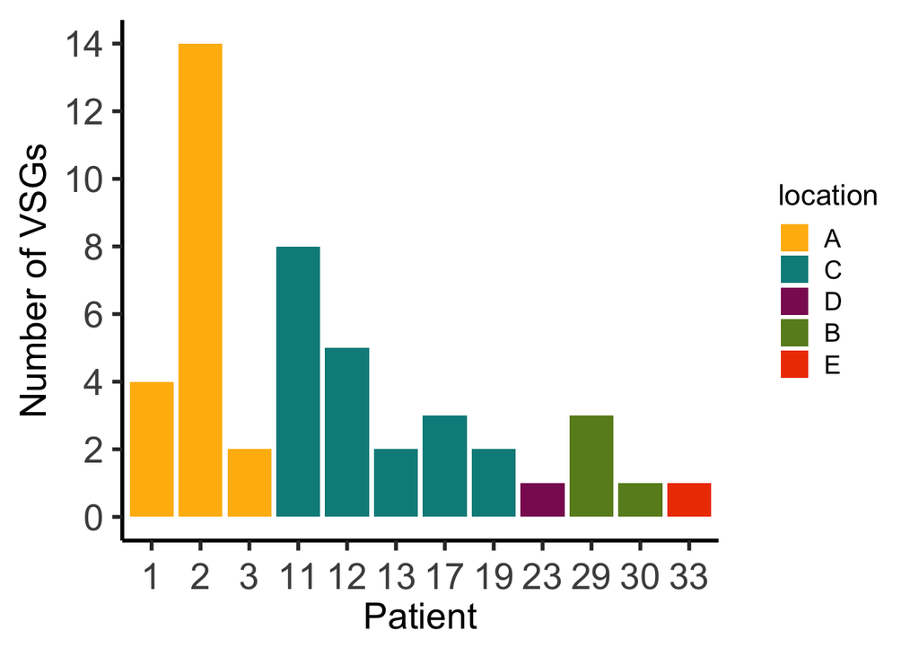

```r
middle_unique$patient_number <- factor(middle_unique$patient_number, levels = c("1", "2", "3", "11", "12", "13", "17", "19", "23", "29", "30", "33"))

middle_patient_VSGs.graph = middle_unique %>%
  ggplot(aes(x = patient_number, group = patient_number, fill=location))+
  geom_bar(stat = "count", size = 0.8, y=0.2, position = position_dodge())+
  theme_classic(base_size = 22)+
  scale_y_continuous(breaks = scales::pretty_breaks(n = 6))+
  scale_fill_manual(values = c("A"="darkgoldenrod1",
                               "C"="darkcyan",
                               "D"="maroon4",
                               "B"="olivedrab4",
                               "E"="orangered2"))+
  #geom_text(stat='count', aes(label=..count..), vjust=-0.4)+
  theme(axis.text.x = element_text(angle = 0, vjust = 0.5, size = 20), axis.text.y = element_text(size = 20), axis.title = element_text(size = 20),legend.title = element_text(size = 16), legend.text = element_text(size = 14))+
  labs(x = "Patient", y = "Number of VSGs")
middle_patient_VSGs.graph
```

#### **QUESTION: Are any VSGs shared between patients?**

Here, I make an UpSet plot conveying the VSGs in common among patients after a 1% cutoff AND selection for VSGs present in 2+ replicates.

The UpSet plot uses the upset function with a list as the argument. The list contains variables, named for each of the "items" to be compared to one another (eg. patient1, patient2, patient3, etc.) To compare the VSGs/clusters between patients, I search the cluster column and specify each patient in separate variables. The patient_number column was originally a factor, but is converted to a character for parsing purposes.

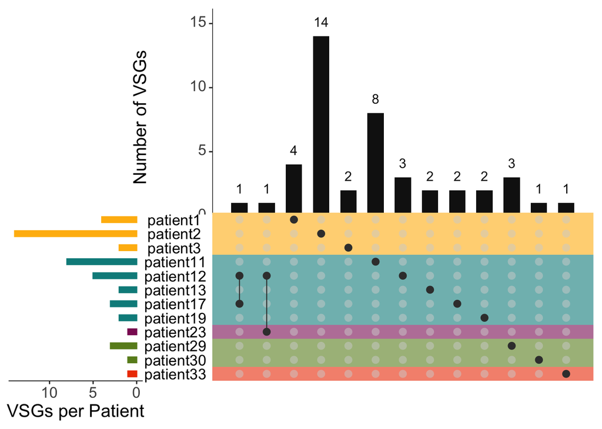

extract categories from upset plot

## Plotting filtered VSG dataset

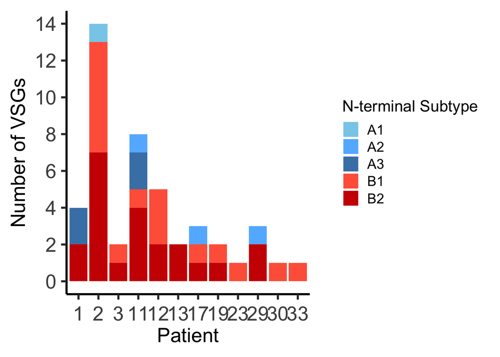

```r
#palette <- c("#ffdec2", "#fcab64", "#f27618", "#91a6b4", "#02263d")
palette <- c("skyblue", "steelblue1", "steelblue", "tomato", "red3", "lightgrey")
# plot number of VSG by type per patient
a1 <- middle_unique %>% dplyr::group_by(patient_number, nterm_typesubtype) %>%
  dplyr::summarise(total = n()) %>%
  ggplot(aes(x = patient_number, y = total, fill = nterm_typesubtype)) +
  geom_bar(stat = "identity", size = 0.8) +
  scale_fill_manual(values = palette) +
  scale_y_continuous(breaks = scales::pretty_breaks(n = 6)) +
  theme_classic(base_size = 22) +
  ylab("Number of VSGs") +
  labs(fill = "N-terminal Subtype") +
  theme(axis.text.x = element_text(angle = 0, vjust = 0.5, size = 20), axis.text.y = element_text(size = 20), axis.title = element_text(size = 20),legend.title = element_text(size = 16), legend.text = element_text(size = 14))+
  xlab("Patient")
a1
```

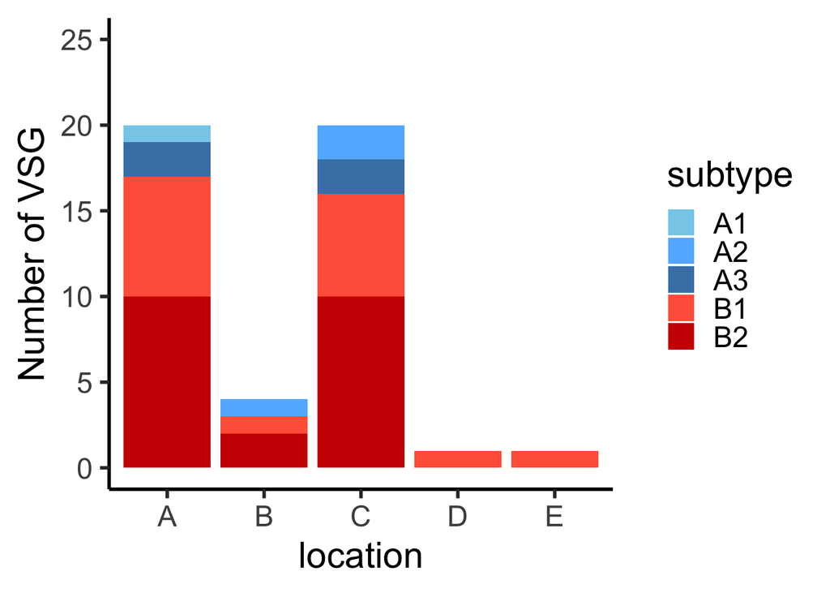

```r
# by region
a2 <- middle_unique %>% dplyr::group_by(location, nterm_typesubtype) %>%
  dplyr::summarise(total = n()) %>%
  ggplot(aes(x = location, y = total, fill = nterm_typesubtype)) +
  geom_bar(stat = "identity") +
  scale_fill_manual(values = palette) +
  scale_y_continuous(limits = c(0, 25)) +
  theme_classic(base_size = 22) +
  ylab("Number of VSG") +
  labs(fill = "subtype") +
  xlab("location")
a2
```

```r
# percents
sums <- middle_unique %>% dplyr::group_by(patient_number, nterm_typesubtype) %>%
  dplyr::summarise(n = n())
pct <- sums %>% dplyr::group_by(patient_number) %>% dplyr::summarize(total = sum(n)) %>% merge(sums, by = "patient_number")
pct$pct <- (pct$n / pct$total) * 100
pct
```

```
##    patient_number total nterm_typesubtype n        pct
## 1               1     4                A3 2  50.000000
## 2               1     4                B2 2  50.000000
## 3              11     8                A2 1  12.500000
## 4              11     8                A3 2  25.000000
## 5              11     8                B1 1  12.500000
## 6              11     8                B2 4  50.000000
## 7              12     5                B1 3  60.000000
## 8              12     5                B2 2  40.000000
## 9              13     2                B2 2 100.000000
## 10             17     3                A2 1  33.333333
## 11             17     3                B1 1  33.333333
## 12             17     3                B2 1  33.333333
## 13             19     2                B1 1  50.000000
## 14             19     2                B2 1  50.000000
## 15              2    14                A1 1   7.142857
## 16              2    14                B1 6  42.857143
## 17              2    14                B2 7  50.000000
## 18             23     1                B1 1 100.000000
## 19             29     3                A2 1  33.333333
## 20             29     3                B2 2  66.666667
## 21              3     2                B1 1  50.000000
## 22              3     2                B2 1  50.000000
## 23             30     1                B1 1 100.000000
## 24             33     1                B1 1 100.000000
```

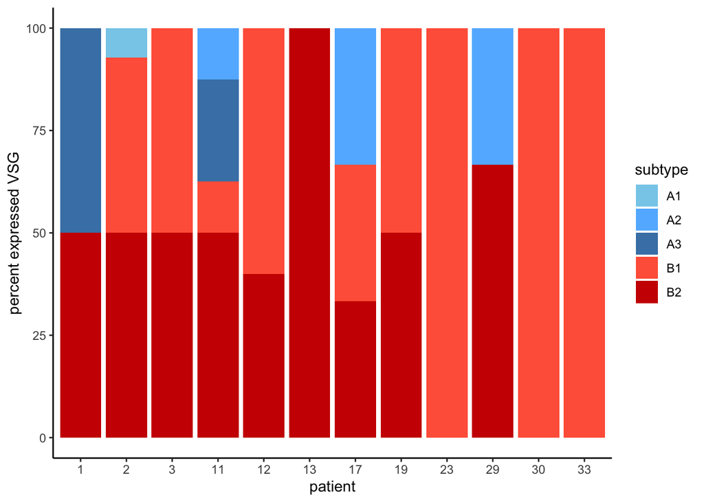

```r
a3 <-
  ggplot(pct, aes(x = patient_number, y = pct, fill = nterm_typesubtype)) +
  geom_bar(stat = "identity") +
  scale_fill_manual(values = palette) +
  scale_y_continuous(limits = c(0, 100)) +
  theme_classic() +
  ylab("percent expressed VSG") +
  labs(fill = "subtype") +
  xlab("patient")
a3
```

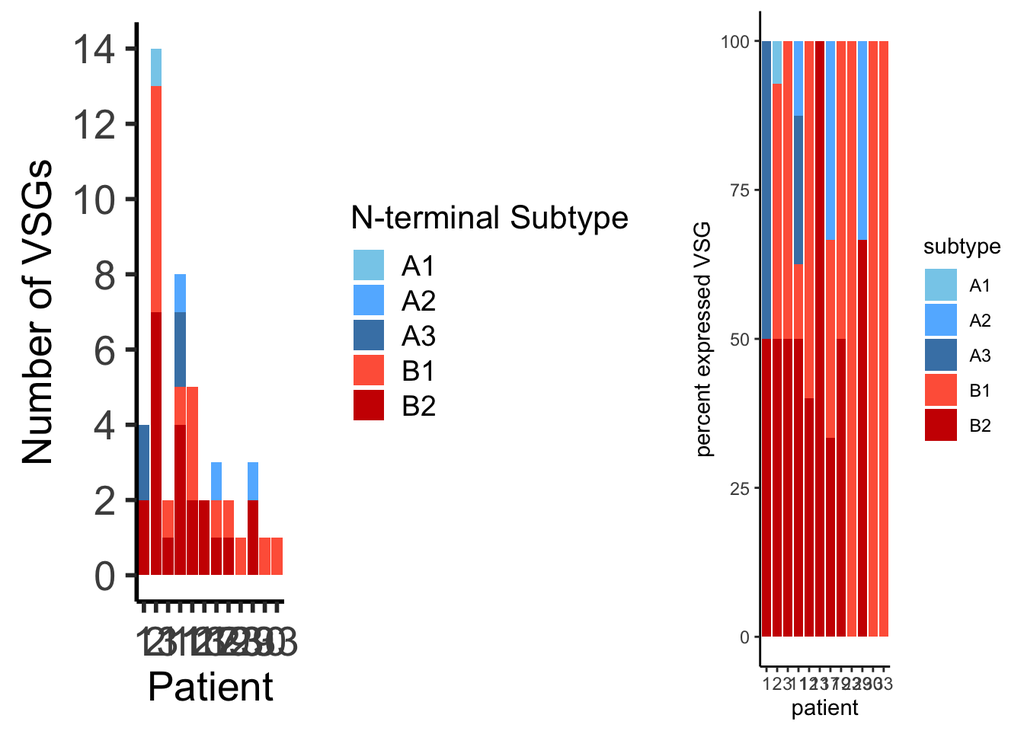

```r
plot_grid(a1, a3, rel_widths = c(2,1))
```

## Plot VSG type distribution

data not filtered by expression level total number of VSG types assembled in merged patient dataset

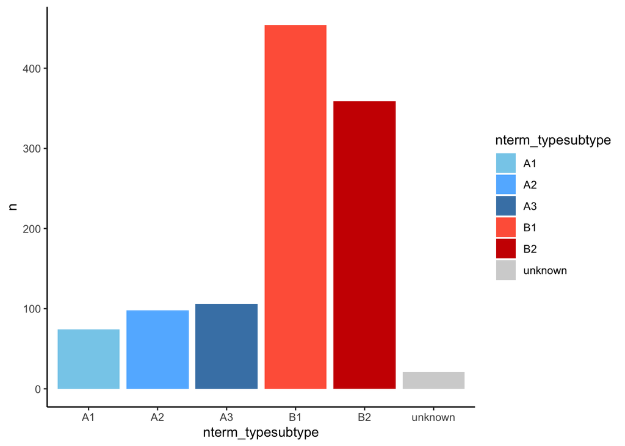

```r
# do not apply filters by expression level, consider all assembled VSG
# Plot number of VSGs by assigned type to see the distribution of type expression
SSE0_VSGs_Nterm$nterm_typesubtype <- as.character(SSE0_VSGs_Nterm$nterm_typesubtype)

SSE0_VSGs_Nterm %>% mutate(nterm_typesubtype = replace_na(nterm_typesubtype, "unknown")) %>% dplyr::group_by(nterm_typesubtype) %>% dplyr::summarise(n = n()) %>%
  ggplot(aes(x = nterm_typesubtype, y = n, fill = nterm_typesubtype)) +
  geom_bar(stat = "identity") +
  scale_fill_manual(values = palette) +
  theme_classic()
```

```r
SSE0_VSGs_Nterm %>% mutate(nterm_typesubtype = replace_na(nterm_typesubtype, "unknown")) %>% dplyr::group_by(nterm_typesubtype) %>% dplyr::summarise(n = n())
```

```
## # A tibble: 6 x 2
##   nterm_typesubtype     n
##   <chr>             <int>
## 1 A1                   74
## 2 A2                   98
## 3 A3                  106
## 4 B1                  454
## 5 B2                  359
## 6 unknown              21
```

```r
# definitely more B types assembled from the read set. they do not just dominate by being the most highly expressed type
```

## Add N-term type data to the cluster heatmap

Here, I make a heatmap with all 108 clusters and 12 patients.

```r
allpatients_hm = SSE0_VSGs_Final_Mergedl %>% select(file, Percent, cluster)
allpatients_hm_data = allpatients_hm
colnames(allpatients_hm_data) <- c("file", "value", "cluster")
#p1_heatmap.data$file <- unlist(p1_heatmap.data$file)
#allpatients_hm_data <- unique(allpatients_hm_data) #why is this here?
#p1_heatmap.data$value <- unlist(p1_heatmap.data)
allpatients_hm_data
```

```
## # A tibble: 185 x 3
##    file     value cluster
##    <chr>    <dbl> <chr>
##  1 01S_1.fq 26.1  Cluster 255
##  2 01S_1.fq 10.7  Cluster 40
##  3 01S_1.fq  9.18 Cluster 987
##  4 01S_1.fq  8.27 Cluster 959
##  5 01S_1.fq  8.88 Cluster 370
##  6 01S_1.fq 12.9  Cluster 60
##  7 01S_1.fq 23.4  Cluster 452
##  8 01S_2.fq  4.69 Cluster 255
##  9 01S_2.fq 28.7  Cluster 370
## 10 01S_2.fq  1.75 Cluster 452
## # … with 175 more rows
```

```r
allpatients_hm_data_c <- dcast(allpatients_hm_data, cluster ~ file, value.var = "value")
allpatients_hm_data_c
```

```
##         cluster  01S_1.fq  01S_2.fq  01S_3.fq  02S_1.fq  02S_2.fq  02S_3.fq
## 1   Cluster 109        NA  3.174720        NA        NA        NA        NA
## 2   Cluster 114        NA        NA        NA  1.459251  3.424012  4.055665
## 3   Cluster 119        NA        NA        NA        NA        NA        NA
## 4   Cluster 127        NA        NA        NA        NA        NA        NA
## 5   Cluster 135        NA        NA  3.975888        NA        NA        NA
## 6   Cluster 136        NA        NA  3.997464        NA        NA        NA
## 7   Cluster 159        NA        NA        NA        NA        NA        NA
## 8   Cluster 169        NA        NA        NA        NA        NA        NA
## 9   Cluster 173        NA        NA        NA        NA        NA        NA
## 10  Cluster 174        NA        NA        NA        NA        NA        NA
## 11  Cluster 175        NA        NA        NA        NA        NA        NA
## 12  Cluster 195        NA        NA        NA        NA        NA        NA
## 13    Cluster 2        NA        NA        NA        NA        NA        NA
## 14  Cluster 206        NA        NA        NA        NA        NA        NA
```

[output cut: 530 more lines]

```r
allpatients_hm_data_c2 <- allpatients_hm_data_c[2:length(allpatients_hm_data_c)]
rownames(allpatients_hm_data_c2) <- allpatients_hm_data_c$cluster
allpatients_hm_m <- as.matrix(allpatients_hm_data_c2)
allpatients_hm_m <- allpatients_hm_m[order(-rowMeans(allpatients_hm_m)),]
allpatients_hm_m[is.na(allpatients_hm_m)] <- 0
allpatients_hm_m <- allpatients_hm_m + 0.1
allpatients_hm_m <- log10(allpatients_hm_m)
allpatients_hm_m
```

```
##               01S_1.fq   01S_2.fq   01S_3.fq    02S_1.fq    02S_2.fq
## Cluster 109 -1.0000000  0.5151742 -1.0000000 -1.00000000 -1.00000000
## Cluster 114 -1.0000000 -1.0000000 -1.0000000  0.19291599  0.54703734
## Cluster 119 -1.0000000 -1.0000000 -1.0000000 -1.00000000 -1.00000000
## Cluster 127 -1.0000000 -1.0000000 -1.0000000 -1.00000000 -1.00000000
## Cluster 135 -1.0000000 -1.0000000  0.6102223 -1.00000000 -1.00000000
## Cluster 136 -1.0000000 -1.0000000  0.6125151 -1.00000000 -1.00000000
## Cluster 159 -1.0000000 -1.0000000 -1.0000000 -1.00000000 -1.00000000
## Cluster 169 -1.0000000 -1.0000000 -1.0000000 -1.00000000 -1.00000000
## Cluster 173 -1.0000000 -1.0000000 -1.0000000 -1.00000000 -1.00000000
## Cluster 174 -1.0000000 -1.0000000 -1.0000000 -1.00000000 -1.00000000
## Cluster 175 -1.0000000 -1.0000000 -1.0000000 -1.00000000 -1.00000000
## Cluster 195 -1.0000000 -1.0000000 -1.0000000 -1.00000000 -1.00000000
## Cluster 2   -1.0000000 -1.0000000 -1.0000000 -1.00000000 -1.00000000
## Cluster 206 -1.0000000 -1.0000000 -1.0000000 -1.00000000 -1.00000000
## Cluster 21  -1.0000000 -1.0000000 -1.0000000 -1.00000000 -1.00000000
## Cluster 218 -1.0000000 -1.0000000 -1.0000000  0.20978503  0.57881311
## Cluster 22  -1.0000000 -1.0000000 -1.0000000 -1.00000000 -1.00000000
## Cluster 234 -1.0000000 -1.0000000 -1.0000000 -1.00000000 -1.00000000
## Cluster 235 -1.0000000 -1.0000000 -1.0000000 -1.00000000 -1.00000000
## Cluster 238 -1.0000000 -1.0000000 -1.0000000 -1.00000000 -1.00000000
## Cluster 239 -1.0000000 -1.0000000 -1.0000000 -1.00000000 -1.00000000
## Cluster 240 -1.0000000 -1.0000000 -1.0000000 -1.00000000  0.32597382
## Cluster 242 -1.0000000 -1.0000000 -1.0000000 -1.00000000 -1.00000000
## Cluster 248 -1.0000000 -1.0000000 -1.0000000 -1.00000000 -1.00000000
## Cluster 249 -1.0000000 -1.0000000 -1.0000000 -1.00000000 -1.00000000
## Cluster 255  1.4174986  0.6800383  1.5792512 -1.00000000 -1.00000000
## Cluster 263 -1.0000000 -1.0000000 -1.0000000 -1.00000000 -1.00000000
## Cluster 265 -1.0000000 -1.0000000 -1.0000000 -1.00000000 -1.00000000
## Cluster 266 -1.0000000 -1.0000000 -1.0000000 -1.00000000 -1.00000000
## Cluster 278 -1.0000000 -1.0000000 -1.0000000 -1.00000000 -1.00000000
## Cluster 280 -1.0000000 -1.0000000 -1.0000000 -1.00000000 -1.00000000
## Cluster 285 -1.0000000 -1.0000000 -1.0000000  0.31239345 -1.00000000
## Cluster 286 -1.0000000 -1.0000000 -1.0000000  0.29545758  0.40298641
## Cluster 291 -1.0000000 -1.0000000 -1.0000000 -1.00000000 -1.00000000
## Cluster 3   -1.0000000 -1.0000000 -1.0000000 -1.00000000 -1.00000000
## Cluster 301 -1.0000000 -1.0000000 -1.0000000 -1.00000000 -1.00000000
## Cluster 304 -1.0000000 -1.0000000 -1.0000000  0.08613104  0.15529334
## Cluster 32  -1.0000000 -1.0000000 -1.0000000 -1.00000000 -1.00000000
## Cluster 321 -1.0000000 -1.0000000 -1.0000000  0.20575570 -1.00000000
```

[output cut: 708 more lines]

```
## Cluster 829 -1.000000
## Cluster 835 -1.000000
## Cluster 84  -1.000000
## Cluster 846 -1.000000
## Cluster 874 -1.000000
## Cluster 88  -1.000000
## Cluster 882 -1.000000
## Cluster 89  -1.000000
## Cluster 90  -1.000000
## Cluster 959 -1.000000
## Cluster 968 -1.000000
## Cluster 97  -1.000000
## Cluster 973 -1.000000
## Cluster 984 -1.000000
## Cluster 987 -1.000000
```

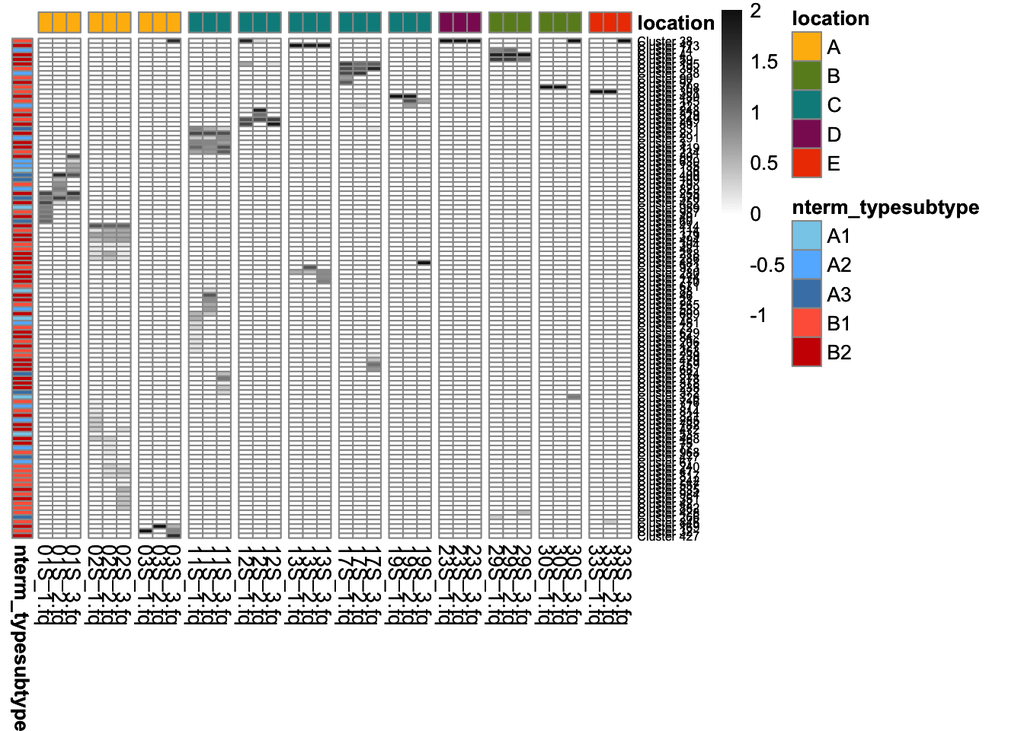

```r
# color columns by location
ALLannotation.df <- data.frame(unique(SSE0_VSGs_Final_Mergedl[c(1,8)]))
colnames(ALLannotation.df) <- c("file", "location")
rownames(ALLannotation.df) <- ALLannotation.df$file[]
ALLannotation.df <- ALLannotation.df %>%
  select(location)

# color rows by VSG n-terminal subtype
Alltypes.df <- data.frame(unique(SSE0_VSGs_typedFinal %>% select(cluster, nterm_typesubtype)))
colnames(Alltypes.df) <- c("cluster", "nterm_typesubtype")
rownames(Alltypes.df) <- Alltypes.df$cluster[]
Alltypes.df <- Alltypes.df %>% select(nterm_typesubtype)

#palette <- c("skyblue", "steelblue1", "steelblue", "tomato", "red3", "lightgrey")

colors_each = list(location = c("A"="darkgoldenrod1",
                                "B"="olivedrab4",
                                "C"="darkcyan",
                                "D"="maroon4",
                                "E"="orangered2"),
                   nterm_typesubtype = c("A1"="skyblue",
                                         "A2"="steelblue1",
                                         "A3"="steelblue",
                                         "B1"="tomato",
                                         "B2"="red3"))

allpatients_heatmap = pheatmap(allpatients_hm_m,
                               breaks = c(seq(-1, -0.1, length.out = 101),
                                          seq(0, 2, length.out = 101)),fontsize_row = 6,
                               show_rownames = T,
                               cluster_cols = F,
                               annotation_col = ALLannotation.df,
                               annotation_row = Alltypes.df,
                               cluster_rows = T,
                               treeheight_row = 0,
                               treeheight_col = 0,
                               color = colorRampPalette(c("white", "white", "gray8"))(201),
                               clustering_method = "complete",
                               gaps_col = c(3,6,9,12,15,18,21,24,27,30,33),
                               annotation_colors = colors_each)
allpatients_heatmap
```

```r
#colorRampPalette(brewer.pal(9, "Greys")(breaks=c(0,1,2)))(110)

#write the types of the VSGs that met the 1% and 2 replicate expression cutoff to file
#write_csv(middle_unique, "SSE0_expressedPatientVSG-types_FINAL.csv")
#write_csv(SSE0_VSGs_typedFinal, path = "SSE0_allTypedPatient_FINAL.csv")
```

### Correlation Plots

```r
# I don't know where Sarah saved her SL-RNA qPCR data
# manually enter mean SL-RNA Ct value from her draft table

SL_Ct <- tibble(patient_number = c(1,2,3,11,12,13,17,19,23,29,30,33),
                meanSL = c(22.155,19.020,28.780,22.030,25.430,26.635,24.495,28.245,27.085,28.320,22.960,32.385))
SL_Ct
```

```
## # A tibble: 12 x 2
##    patient_number meanSL
##             <dbl>  <dbl>
##  1              1   22.2
##  2              2   19.0
##  3              3   28.8
##  4             11   22.0
##  5             12   25.4
##  6             13   26.6
##  7             17   24.5
##  8             19   28.2
##  9             23   27.1
## 10             29   28.3
## 11             30   23.0
## 12             33   32.4
```

```r
gambCorr <- middle_unique %>% group_by(patient_number) %>% summarise(totalVSG = n()) %>% merge(SL_Ct, .)
gambCorr
```

```
##    patient_number meanSL totalVSG
## 1               1 22.155        4
## 2               2 19.020       14
## 3               3 28.780        2
## 4              11 22.030        8
## 5              12 25.430        5
## 6              13 26.635        2
## 7              17 24.495        3
## 8              19 28.245        2
## 9              23 27.085        1
## 10             29 28.320        3
## 11             30 22.960        1
## 12             33 32.385        1
```

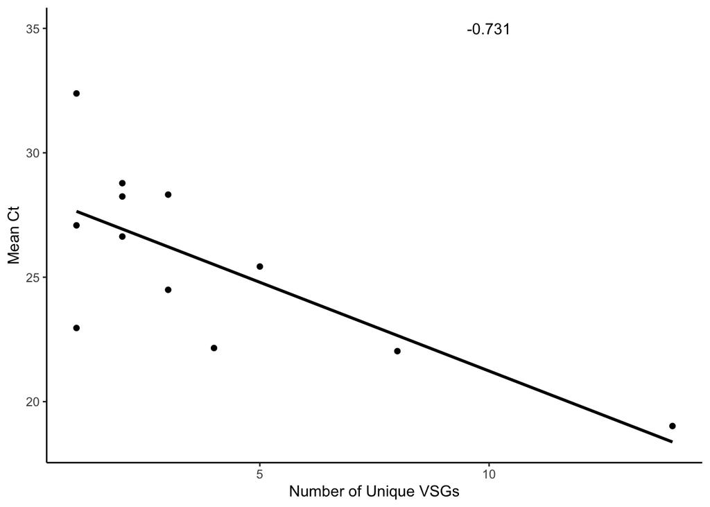

```r
gamb.cor.coeff <- data.frame(cor = as.character(round(cor(gambCorr[ , "totalVSG"], gambCorr[ , "meanSL"], method = "pearson"), digits = 3)),
                      x = c(10),
                      y = c(35))

Ct_VSGs = gambCorr %>%
  ggplot(aes(x=totalVSG, y=meanSL))+
  geom_point(stat = "identity")+
  theme_classic()+
  geom_smooth(method = lm, color = "black", se = FALSE)+
  xlab("Number of Unique VSGs")+
  ylab("Mean Ct")+
  geom_text(data=gamb.cor.coeff, aes(label=cor, x=x, y=y))
Ct_VSGs
```

```r
typeCorr <- middle_unique %>%
  mutate(nterm_type = sub("[[:digit:]]", "", .$nterm_typesubtype)) %>%
  group_by(patient_number, nterm_type) %>%
  summarise(numType = n()) %>%
  merge(gambCorr, ., by="patient_number") %>%
  mutate(pct = (.$numType / .$totalVSG)*100)
typeCorr
```

```
##    patient_number meanSL totalVSG nterm_type numType        pct
## 1               1 22.155        4          A       2  50.000000
## 2               1 22.155        4          B       2  50.000000
## 3               2 19.020       14          A       1   7.142857
## 4               2 19.020       14          B      13  92.857143
## 5               3 28.780        2          B       2 100.000000
## 6              11 22.030        8          A       3  37.500000
## 7              11 22.030        8          B       5  62.500000
## 8              12 25.430        5          B       5 100.000000
## 9              13 26.635        2          B       2 100.000000
## 10             17 24.495        3          A       1  33.333333
## 11             17 24.495        3          B       2  66.666667
## 12             19 28.245        2          B       2 100.000000
## 13             23 27.085        1          B       1 100.000000
## 14             29 28.320        3          A       1  33.333333
## 15             29 28.320        3          B       2  66.666667
## 16             30 22.960        1          B       1 100.000000
## 17             33 32.385        1          B       1 100.000000
```

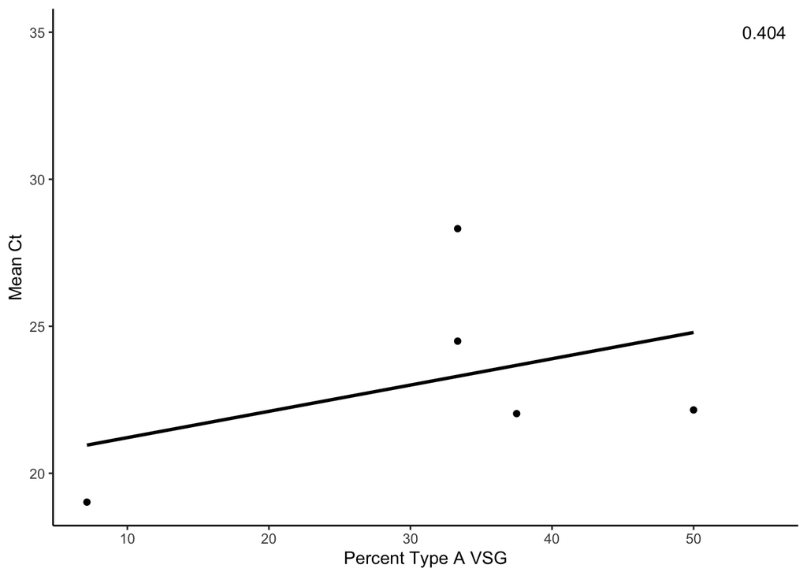

```r
A.cor.coeff <- data.frame(cor = as.character(round(cor(typeCorr[typeCorr$nterm == "A" , ] %>% .$pct , typeCorr[typeCorr$nterm == "A" , ] %>% .$meanSL, method = "pearson"), digits = 3)),
                      x = c(55),
                      y = c(35))

VSGsA <- typeCorr[typeCorr$nterm == "A",] %>%
  ggplot(aes(x=pct, y=meanSL))+
  geom_point(stat = "identity")+
  geom_smooth(method = lm, color = "black", se = FALSE)+
  xlab("Percent Type A VSG")+
  ylab("Mean Ct")+
  geom_text(data=A.cor.coeff, aes(label=cor, x=x, y=y))+
  theme_classic()
VSGsA
```

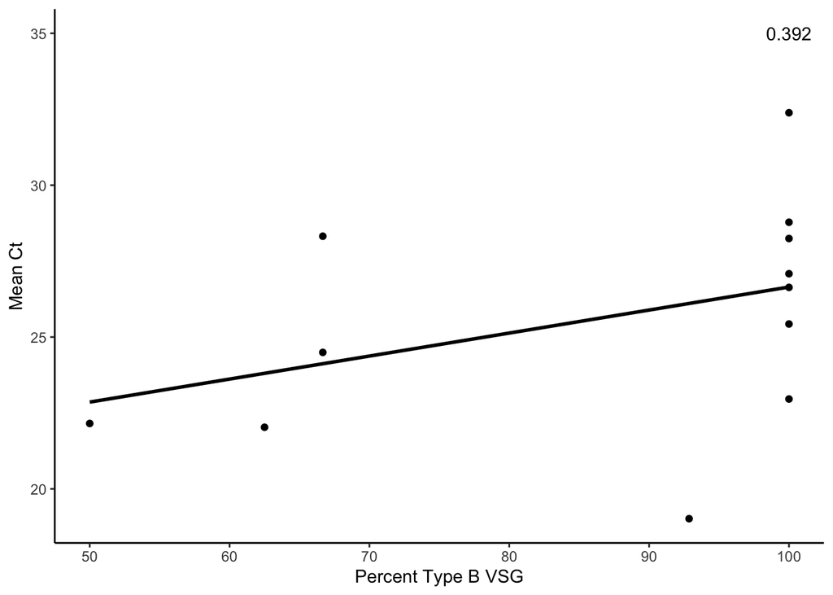

```r
B.cor.coeff <- data.frame(cor = as.character(round(cor(typeCorr[typeCorr$nterm == "B" , ] %>% .$pct , typeCorr[typeCorr$nterm == "B" , ] %>% .$meanSL, method = "pearson"), digits = 3)),
                      x = c(100),
                      y = c(35))

VSGsB <- typeCorr[typeCorr$nterm == "B",] %>%
  ggplot(aes(x=pct, y=meanSL))+
  geom_point(stat = "identity")+
  geom_smooth(method = lm, color = "black", se = FALSE)+
  xlab("Percent Type B VSG")+
  ylab("Mean Ct")+
  geom_text(data=B.cor.coeff, aes(label=cor, x=x, y=y))+
  theme_classic()
VSGsB
```

```r
# consider all assembled VSG that could be typed by HMM-profiles
SSE0_Assembled <- SSE0_VSGs_Nterm[complete.cases(SSE0_VSGs_Nterm),]
length(unique(SSE0_Assembled$cluster))
```

```
## [1] 1091
```

```r
# the number of B-types
summary(SSE0_Assembled[SSE0_Assembled$nterm_typesubtype == "B1" | SSE0_Assembled$nterm_typesubtype == "B2", ])
```

```
##      VSG            original_seq_length nterm_seq_length
##  Length:813         Min.   :151.0       Min.   : 95
##  Class :character   1st Qu.:366.0       1st Qu.:324
##  Mode  :character   Median :446.0       Median :382
##                     Mean   :416.3       Mean   :349
##                     3rd Qu.:479.0       3rd Qu.:396
##                     Max.   :573.0       Max.   :486
##                HMM_profile  nterm_typesubtype    cluster
##  None                :  0   Length:813         Length:813
##  VSG-N-DomainBoundary:  0   Class :character   Class :character
##  VSG-N-TypeA         :  0   Mode  :character   Mode  :character
##  VSG-N-TypeB         :813
##
##
```

```r
dev.off()
```